# QC-espresso - DIA

Quality control report for DIA proteomics data

Author

Guilherme Lanfredi

Published

October 6, 2026

Abstract

This report provides a structured quality control assessment of data-independent acquisition (DIA) proteomics experiments processed with DIA-NN. The analysis supports instrument performance monitoring, dataset validation, and QC tracking.

**WarningRuns excluded by global confidence filtering**

**3 acquisition run(s) were completely removed after decoy exclusion and application of `PG.Q.Value <= 0.01`.**

**Affected run(s):** 17, 18, 19

These runs are absent from downstream QC outputs because no entries remained after the initial confidence filter.

# 1. Identification performance

**NoteIdentification depth**

This section reports **identification depth per run** at the **precursor**, **peptide**, and **protein‑group** levels.

These levels capture complementary aspects of identification performance: precursor counts reflect charge‑ and modification‑specific signals, peptides provide a more stable sequence‑level view, and protein groups summarize identification at the inference level used for downstream analyses.

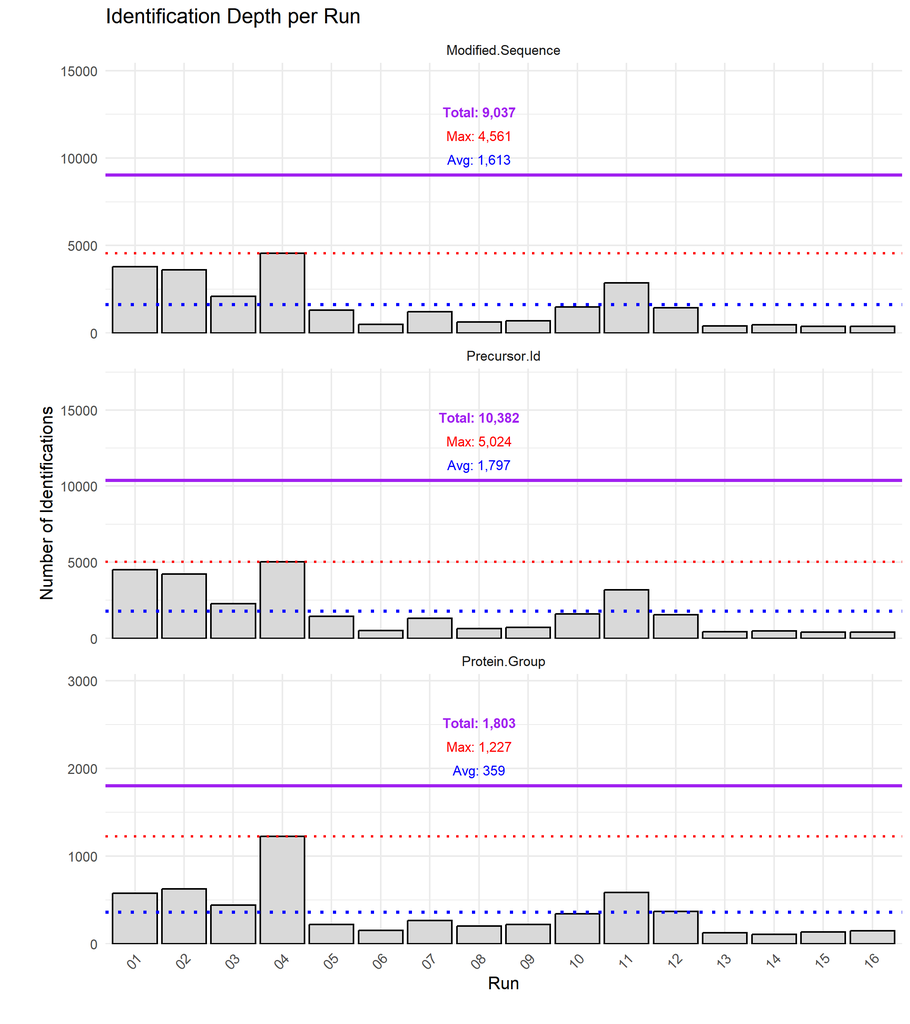

Identification Depth per Run

Precursors, peptides, and protein groups

| Run | Precursors | Peptides | Protein.Groups |
| --- | --- | --- | --- |
| 01 | 4,519 | 3,785 | 577 |
| 02 | 4,214 | 3,604 | 627 |
| 03 | 2,276 | 2,098 | 442 |
| 04 | 5,024 | 4,561 | 1,227 |
| 05 | 1,457 | 1,310 | 221 |
| 06 | 520 | 497 | 153 |
| 07 | 1,314 | 1,216 | 264 |
| 08 | 654 | 618 | 201 |
| 09 | 722 | 694 | 222 |
| 10 | 1,609 | 1,487 | 342 |
| 11 | 3,191 | 2,860 | 584 |
| 12 | 1,548 | 1,444 | 371 |
| 13 | 424 | 408 | 124 |
| 14 | 479 | 455 | 110 |
| 15 | 400 | 380 | 135 |
| 16 | 397 | 386 | 150 |

TOTAL across all runs - Peptides: 9,037; Precursors: 10,382; Protein Groups: 1,803

# 2. Quantitative signal composition

**NoteRelative abundance and contaminant contribution**

This section summarizes the **relative distribution of protein‑level signal across runs**, including the fraction attributed to protein groups annotated as contaminants.

Relative abundance profiles provide a concise assessment of sample composition and quantitative balance between runs. Consistent patterns indicate stable sample preparation and instrument response, whereas pronounced shifts may reflect differences in sample loading, background contamination, or overall signal balance.

Contaminant-specific plots highlight signal originating from common background proteins (e.g. keratins, proteolytic enzymes, laboratory contaminants). Elevated or variable contaminant contributions can affect identification depth and quantitative robustness.

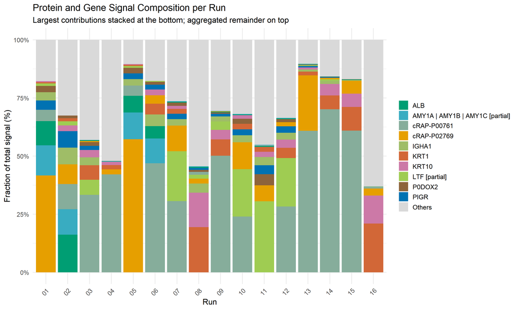

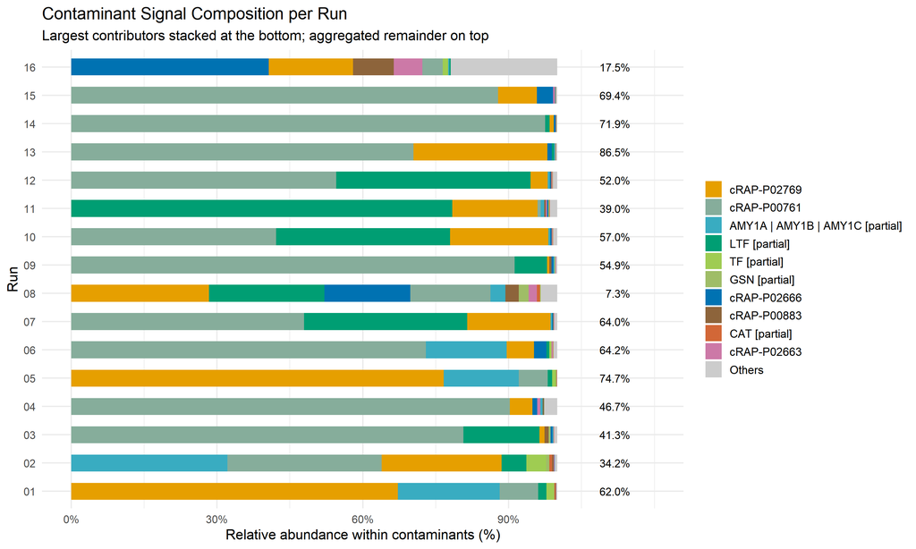

# 3. Sequence coverage

**NoteProtein sequence coverage**

This section summarizes **protein sequence coverage** based on the mapping of identified peptides to reference protein sequences.

Coverage reflects the fraction of amino acid positions supported by at least one peptide. The summary table reports the **top 100 proteins** ranked by sequence coverage, while the density plot provides a global overview of coverage distribution across the proteome.

The complete coverage table, including peptide evidence for all proteins, is exported as a CSV file for reference and downstream inspection. Sequence coverage complements identification depth by describing how extensively individual protein sequences are sampled rather than how many proteins are detected.

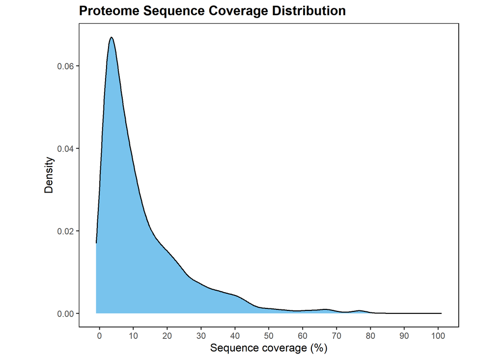

Protein Sequence Coverage Summary (Top 100)

Full peptide evidence is exported as CSV

| Accession | Protein Name | Length (aa) | Covered AA | Coverage (%) |
| --- | --- | --- | --- | --- |
| P0DTE7 | Alpha-amylase 1B | 511 | 395 | 77.3% |
| P0DTE8 | Alpha-amylase 1C | 511 | 395 | 77.3% |
| P0DUB6 | Alpha-amylase 1A | 511 | 395 | 77.3% |
| P02768 | Albumin | 609 | 466 | 76.5% |
| P02788 | Lactotransferrin | 710 | 543 | 76.5% |
| Q9UBC9 | Small proline-rich protein 3 | 169 | 127 | 75.1% |
| P62805 | Histone H4 | 103 | 74 | 71.8% |
| P62937 | Peptidyl-prolyl cis-trans isomerase A | 165 | 114 | 69.1% |
| P60174 | Triosephosphate isomerase | 249 | 171 | 68.7% |
| P01040 | Cystatin-A | 98 | 67 | 68.4% |
| P23528 | Cofilin-1 | 166 | 112 | 67.5% |
| A0A0A0MT89 | Immunoglobulin kappa joining 1 | 12 | 8 | 66.7% |
| P61604 | 10 kDa heat shock protein, mitochondrial | 102 | 68 | 66.7% |
| P12273 | Prolactin-inducible protein | 146 | 97 | 66.4% |
| P08727 | Keratin, type I cytoskeletal 19 | 400 | 265 | 66.2% |
| P07355 | Annexin A2 | 339 | 223 | 65.8% |
| P25311 | Zinc-alpha-2-glycoprotein | 298 | 191 | 64.1% |
| P06899 | Histone H2B type 1-J | 126 | 80 | 63.5% |
| P00558 | Phosphoglycerate kinase 1 | 417 | 263 | 63.1% |
| P62328 | Thymosin beta-4 | 44 | 27 | 61.4% |
| P23284 | Peptidyl-prolyl cis-trans isomerase B | 216 | 132 | 61.1% |
| P35908 | Keratin, type II cytoskeletal 2 epidermal | 639 | 388 | 60.7% |
| P07737 | Profilin-1 | 140 | 85 | 60.7% |
| P14618 | Pyruvate kinase PKM | 531 | 312 | 58.8% |
| P63173 | Large ribosomal subunit protein eL38 | 70 | 40 | 57.1% |
| P01009 | Alpha-1-antitrypsin | 418 | 237 | 56.7% |
| P04083 | Annexin A1 | 346 | 193 | 55.8% |
| P04264 | Keratin, type II cytoskeletal 1 | 644 | 354 | 55% |
| O00299 | Chloride intracellular channel protein 1 | 241 | 130 | 53.9% |
| P05109 | Protein S100-A8 | 93 | 50 | 53.8% |

[output cut: 70 more lines]

# 4. Peptide-level quality

**NotePeptide‑level metrics**

This section summarizes **peptide‑level quality metrics** derived from identified peptides, including precursor **charge‑state distribution**, **peptide length**, and **missed tryptic cleavages**.

Charge‑state distributions reflect precursor ionization behavior and chemistry, while peptide length distributions summarize digestion outcome and peptide detectability. Digestion efficiency is assessed through the fraction of peptides containing at least one missed tryptic cleavage.

Together, these metrics provide complementary information to identification counts by capturing changes in peptide chemistry and digestion performance that may not be evident at the protein level.

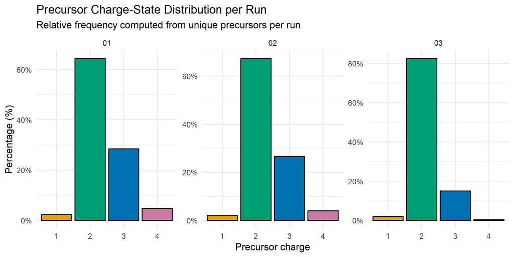

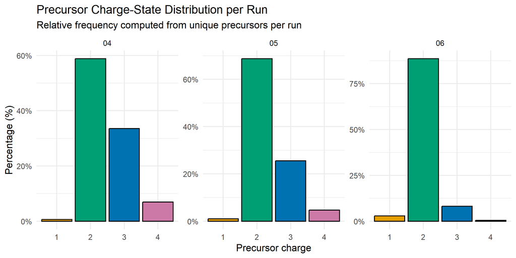

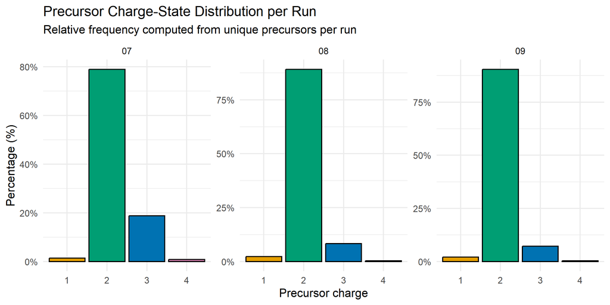

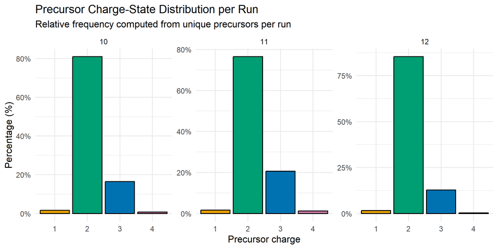

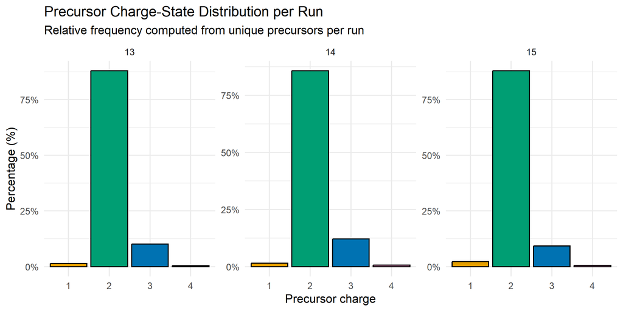

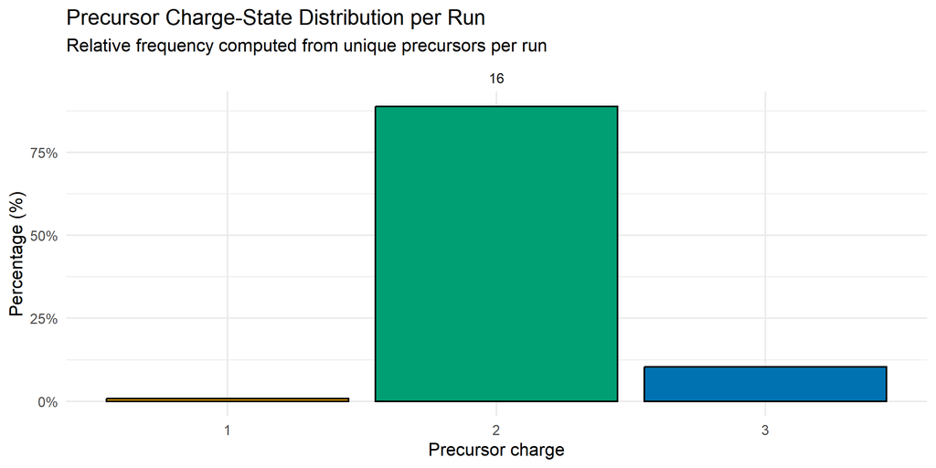

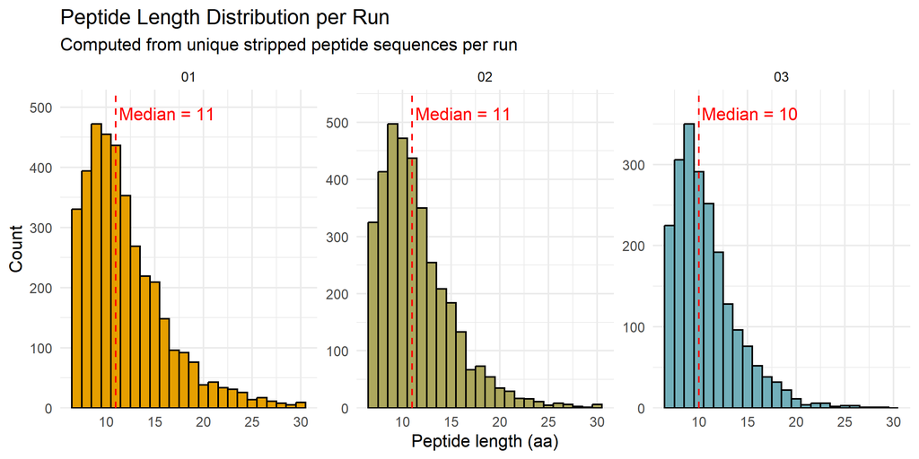

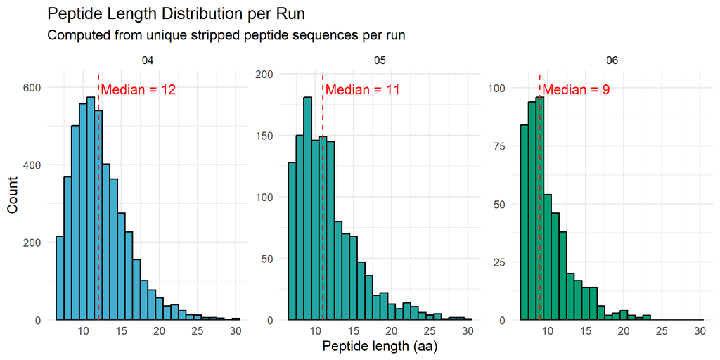

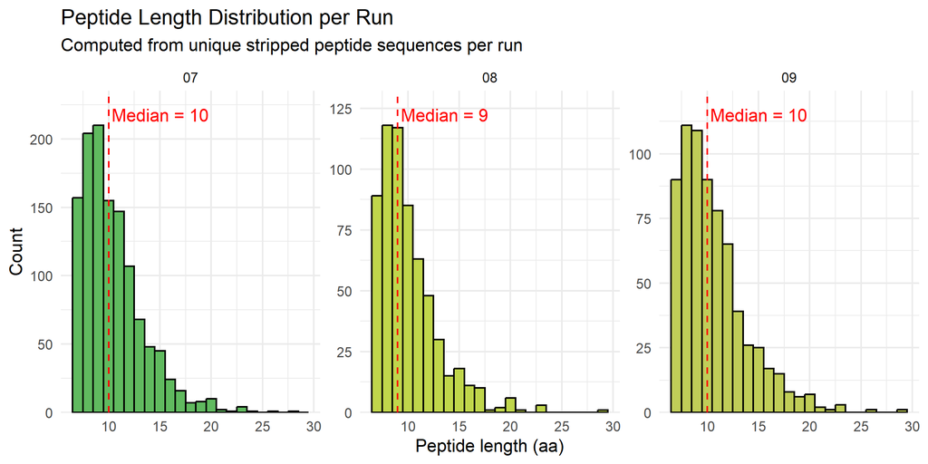

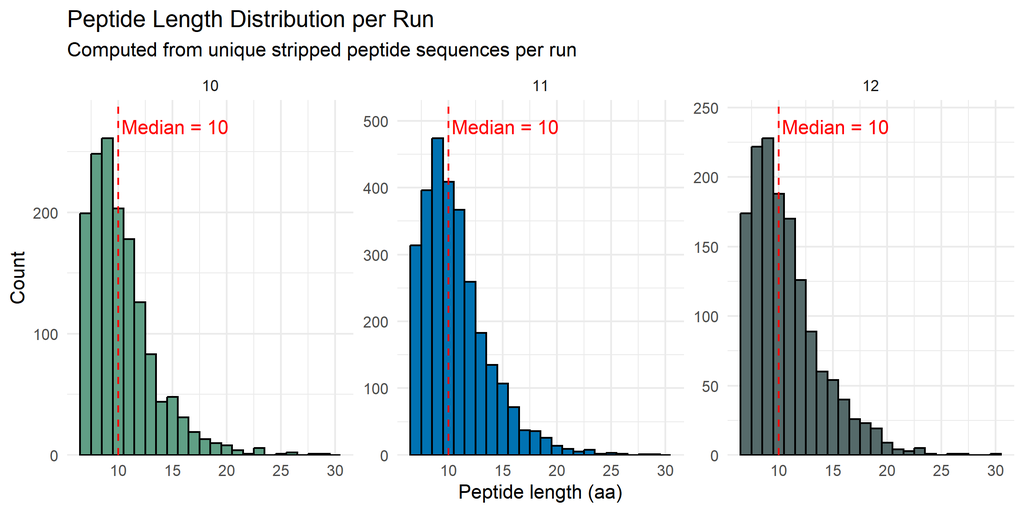

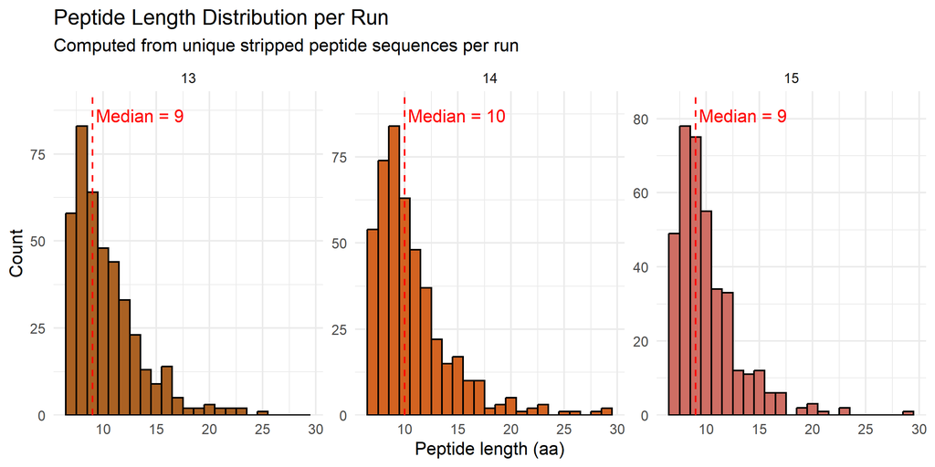

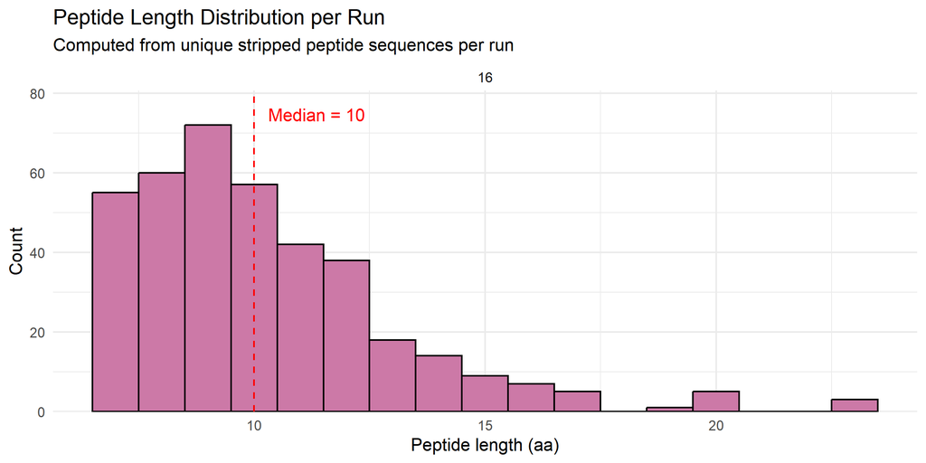

[1 more figures not shown]

# 5. Chromatographic performance

**NoteChromatography quality**

This section evaluates **chromatographic performance and retention‑time behavior** across runs using peptide identification density, peak width metrics, and internal standard monitoring.

Identification density over retention time summarizes how peptide identifications are distributed across the LC gradient, providing an overview of gradient utilization and stability. Peak width metrics, including **full width at half maximum (FWHM)** and **peak base width**, characterize chromatographic peak shape and separation efficiency.

Retention‑time reproducibility and quantitative stability of **trypsin autolysis peptides** are assessed as internal standards, providing an instrument‑ and workflow‑level reference independent of biological variation. Together, these plots highlight changes in chromatographic performance such as gradient drift, peak broadening, or reduced run‑to‑run stability.

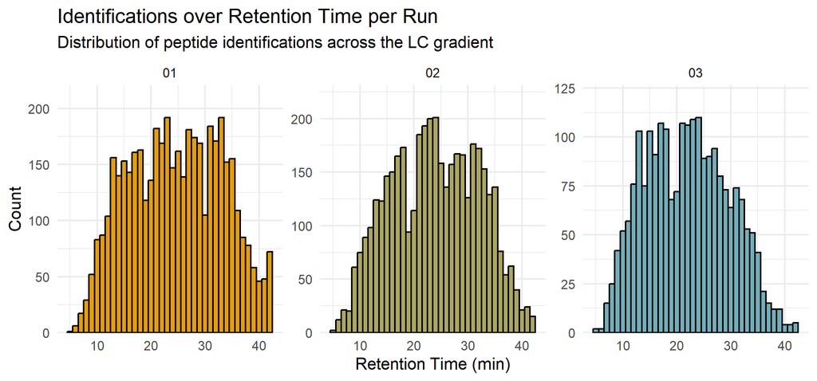

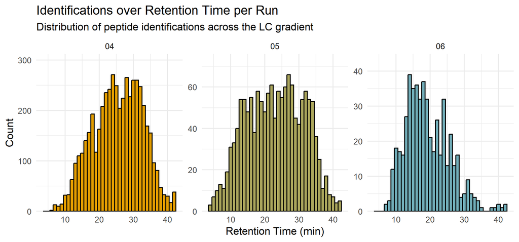

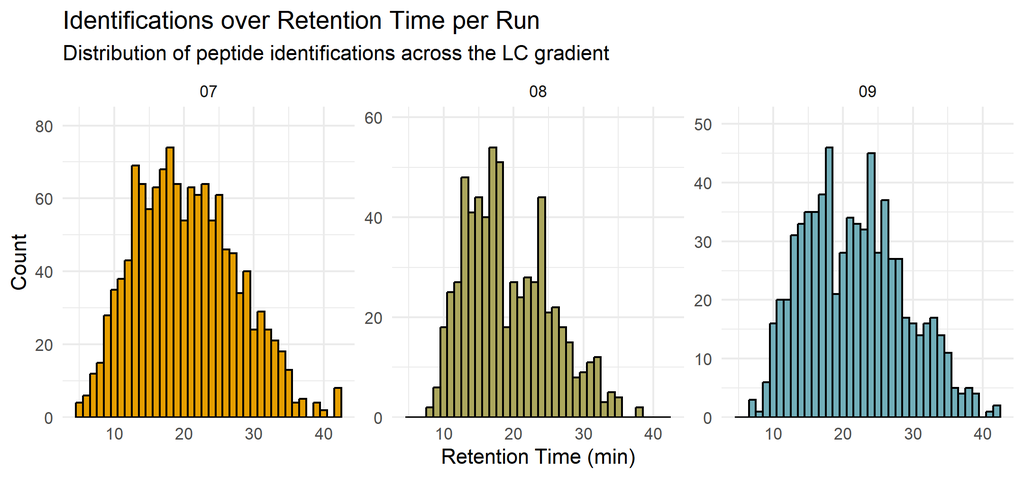

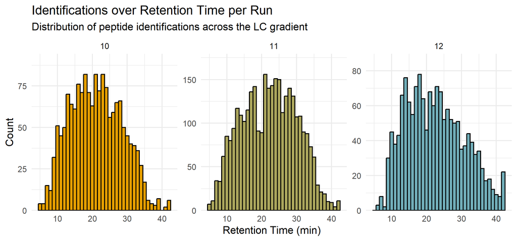

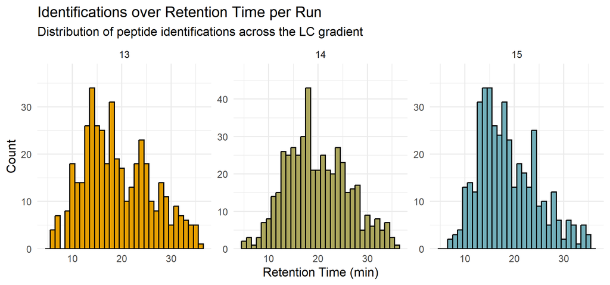

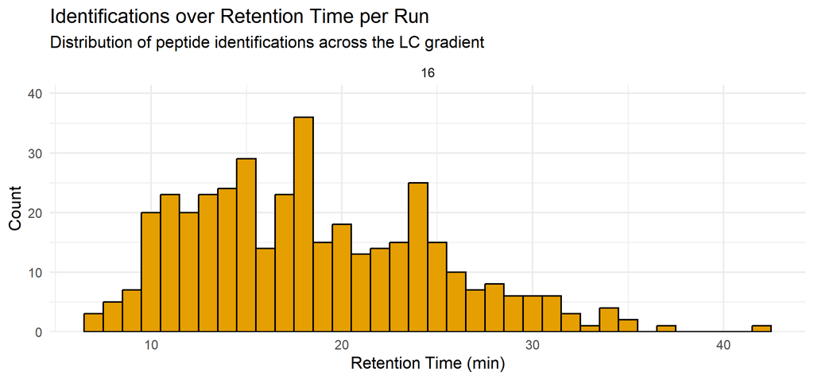

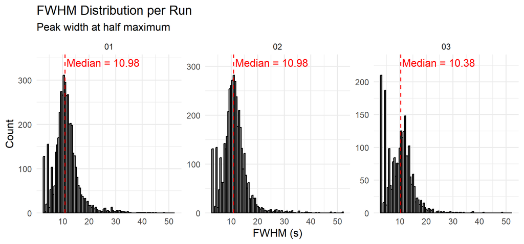

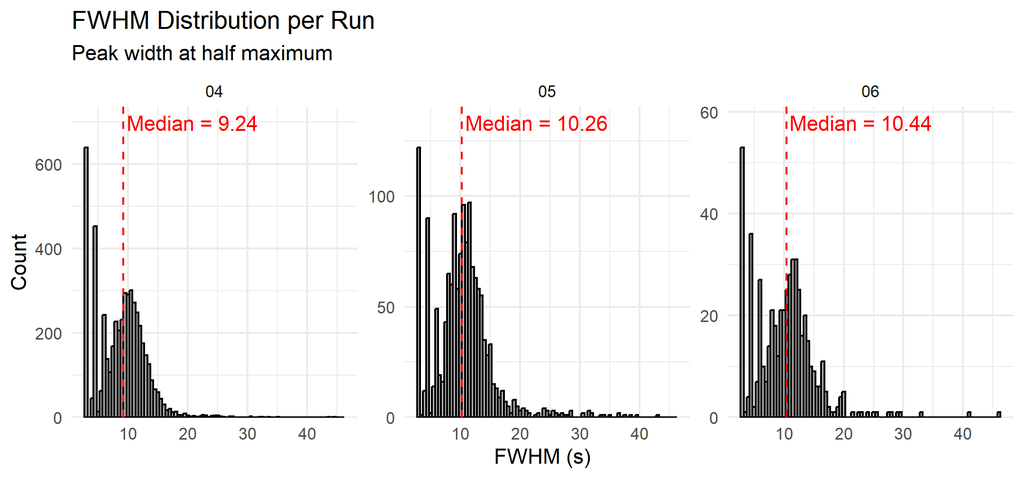

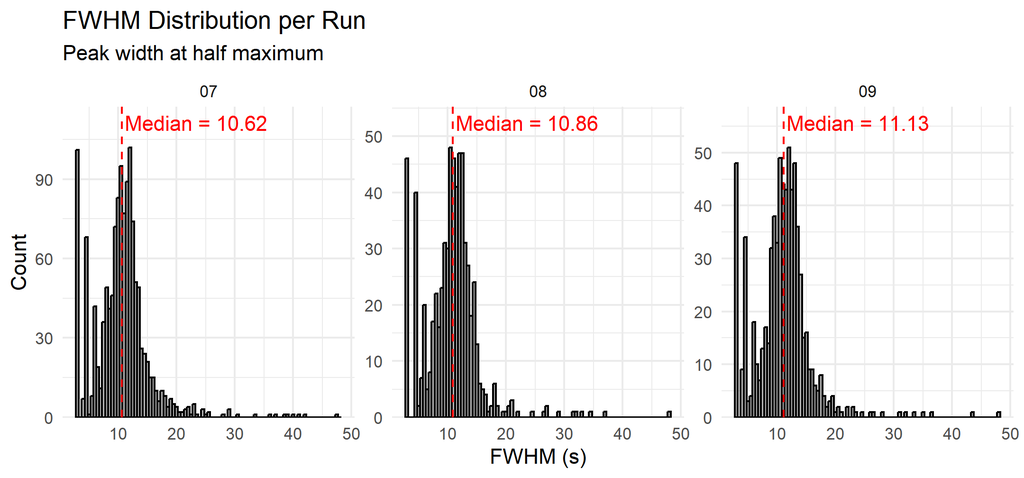

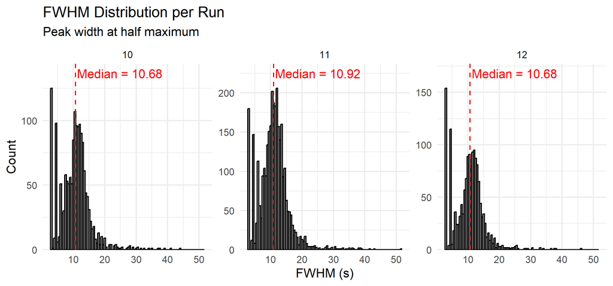

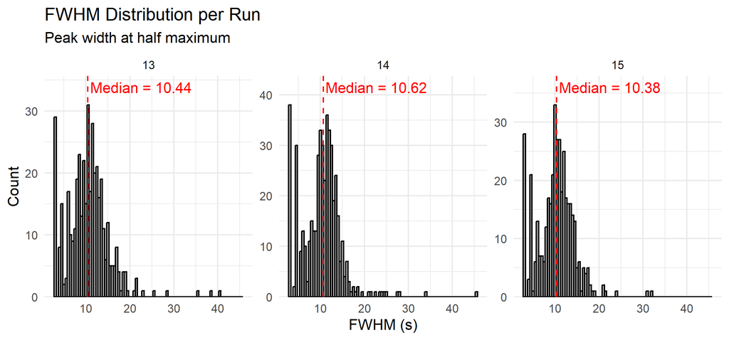

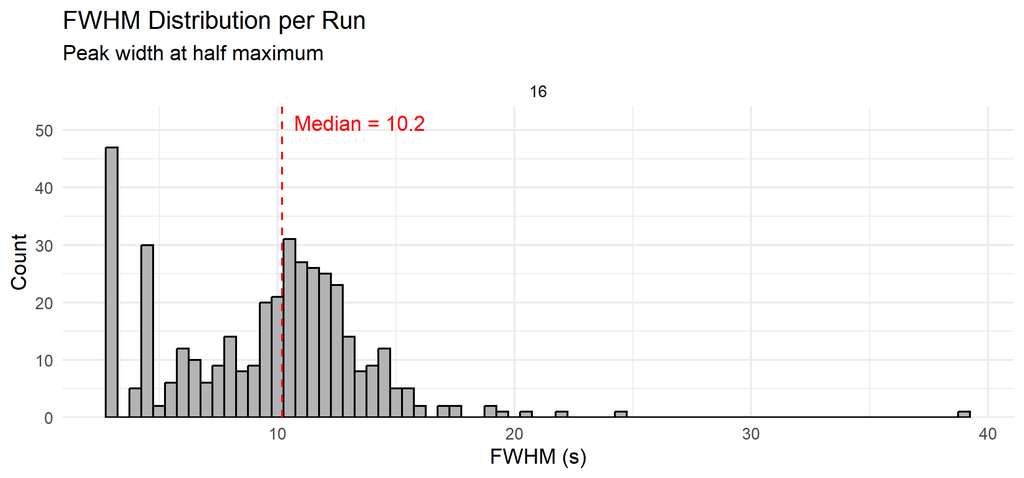

[8 more figures not shown]